# Homework 10

Solutions for Questions 1 and 2 will be available after Monday, November 2, 2026. No solution will be provided for Question 3.

Use the RLT package for Questions 1 and 2: `RLT` in R or `rlt` in Python. The node-size parameter is `nmin` in R and `min_samples_leaf` in Python; both stop splitting a node when it contains at most that many observations. The candidate-predictor parameter is `mtry` in both languages. Use ordinary random forests, with reinforcement turned off.

## Question 1: Bias-variance trade-off simulation

Two important tuning parameters of random forests are node size and `mtry`. We have performed some preliminary analysis in class. The goal of this question is to perform a larger simulation study for these two tuning parameters.

Consider a regression model with five jointly normally distributed predictors. Each predictor has mean 0 and variance 1, and the correlation between any two different predictors is 0.3. The response is

$$Y=X_1+X_3+X_5+\varepsilon,
\qquad \varepsilon\sim N(0,1),$$

where the noise is independent of the predictors. Thus the true regression function is $f(\mathbf{x})=x_1+x_3+x_5$.

1. Set up a simulation study with 100 repetitions. Generate 200 test predictor vectors once and keep them fixed. In each repetition, generate 200 new training observations and use the same training data for all tuning settings. Fit 500-tree forests, drawing 200 observations with replacement for each tree. Make the following two comparisons:
   - Fix `mtry` at 3 and vary node size over $1,5,10,20,30$.
   - Fix node size at 10 and vary `mtry` over $1,2,3,4,5$.

   Leave all other fitting parameters at their defaults. Record the predictions at each test point across repetitions. For each setting, estimate the squared bias and variance at each test point, then average them over the 200 test points. Compare predictions with $f(\mathbf{x})$ when estimating bias. Produce two figures, one for each tuning parameter, showing the averaged squared bias and variance. Set a random seed and report it.

### My answer

Seed: 43210. I generate the 200 test vectors once, then in each of 100 reps draw 200 fresh training rows (same training set across all tuning settings within a rep). Forests have 500 trees with full-size bootstrap samples (`resample_prob=1.0`, `resample_replace=True`), reinforcement off. For each test point, squared bias is (mean prediction over reps minus $f(x)$)² and variance is the prediction variance over reps; both are then averaged over the 200 test points.

```
node size | bias^2  variance  MSE
        1 | 0.1749  0.1996  0.3745
        5 | 0.1781  0.1939  0.3720
       10 | 0.1914  0.1834  0.3748
       20 | 0.2502  0.1680  0.4182
       30 | 0.3325  0.1637  0.4962
mtry      | bias^2  variance  MSE
        1 | 0.5505  0.1160  0.6665
        2 | 0.2652  0.1477  0.4128
        3 | 0.1916  0.1814  0.3731
        4 | 0.1694  0.2106  0.3801
        5 | 0.1596  0.2311  0.3908
```

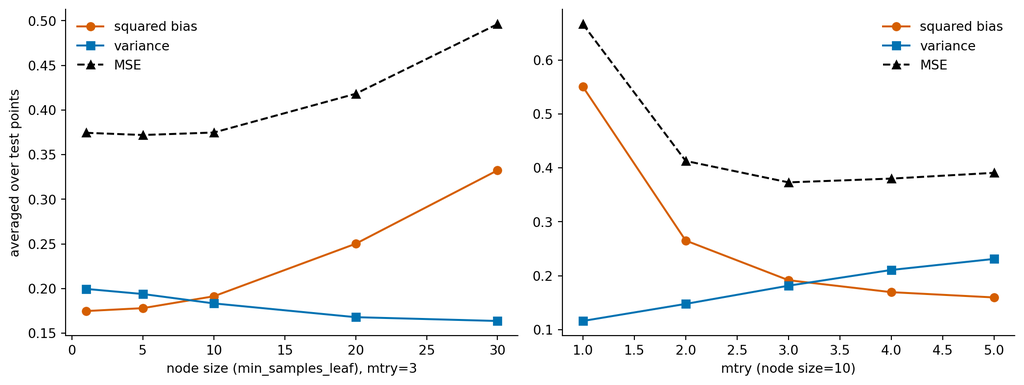

```python
import numpy as np
import matplotlib.pyplot as plt
from rlt.estimators import RLT_reg

SEED = 43210
rng = np.random.default_rng(SEED)
p, rho = 5, 0.3
cov = np.full((p, p), rho); np.fill_diagonal(cov, 1.0)
def f(X): return X[:, 0] + X[:, 2] + X[:, 4]

Xtest = rng.multivariate_normal(np.zeros(p), cov, size=200)
ftest = f(Xtest)
reps = 100
nmins, mtrys = [1, 5, 10, 20, 30], [1, 2, 3, 4, 5]
predA = np.zeros((len(nmins), reps, 200))   # mtry=3, vary node size
predB = np.zeros((len(mtrys), reps, 200))   # node size=10, vary mtry

for r in range(reps):
    Xtr = rng.multivariate_normal(np.zeros(p), cov, size=200)
    ytr = f(Xtr) + rng.normal(size=200)
    for i, nm in enumerate(nmins):
        predA[i, r] = RLT_reg(n_estimators=500, mtry=3, min_samples_leaf=nm,
            resample_replace=True, resample_prob=1.0, reinforcement=False,
            random_state=r*100+i).fit(Xtr, ytr).predict(Xtest)
    for j, mt in enumerate(mtrys):
        predB[j, r] = RLT_reg(n_estimators=500, mtry=mt, min_samples_leaf=10,
            resample_replace=True, resample_prob=1.0, reinforcement=False,
            random_state=r*100+50+j).fit(Xtr, ytr).predict(Xtest)

def bias_var(pred):
    mean = pred.mean(1)
    return ((mean - ftest[None, :])**2).mean(1), pred.var(1).mean(1)

bA, vA = bias_var(predA); bB, vB = bias_var(predB)
print("node size | bias^2  variance  MSE")
for i, nm in enumerate(nmins): print(f"{nm:9d} | {bA[i]:.4f}  {vA[i]:.4f}  {bA[i]+vA[i]:.4f}")
print("mtry      | bias^2  variance  MSE")
for j, mt in enumerate(mtrys): print(f"{mt:9d} | {bB[j]:.4f}  {vB[j]:.4f}  {bB[j]+vB[j]:.4f}")

fig, ax = plt.subplots(1, 2, figsize=(11, 4.2))
ax[0].plot(nmins, bA, "o-", color="#D55E00", label="squared bias")
ax[0].plot(nmins, vA, "s-", color="#0072B2", label="variance")
ax[0].plot(nmins, bA+vA, "^--", color="black", label="MSE")
ax[0].set(xlabel="node size (min_samples_leaf), mtry=3", ylabel="averaged over test points")
ax[1].plot(mtrys, bB, "o-", color="#D55E00", label="squared bias")
ax[1].plot(mtrys, vB, "s-", color="#0072B2", label="variance")
ax[1].plot(mtrys, bB+vB, "^--", color="black", label="MSE")
ax[1].set(xlabel="mtry (node size=10)")
for a in ax: a.legend(frameon=False); a.spines[["top","right"]].set_visible(False)
plt.tight_layout(); plt.show()
```

2. Discuss your results in terms of the bias-variance trade-off:
   - How does a large node size, such as 30, affect the fit in this example?
   - What are the benefits and drawbacks of using a large `mtry` value?
   - If each tree instead sampled 100 observations with replacement, would you expect the preferred node size to shift toward smaller or larger values? Explain your reasoning. You may use an additional simulation to help, but a particular pattern is not guaranteed.

### My answer

**Smaller per-tree samples (100 instead of 200).** I’d expect the preferred node size to shift toward **smaller** values, and a quick sim confirms it:

```python
import numpy as np
from rlt.estimators import RLT_reg

rng = np.random.default_rng(43212)
p = 5; cov = np.full((p, p), 0.3); np.fill_diagonal(cov, 1.0)
def f(X): return X[:, 0] + X[:, 2] + X[:, 4]
Xtest = rng.multivariate_normal(np.zeros(p), cov, 200); ftest = f(Xtest)
nmins = [1, 5, 10, 20, 30]; pred = np.zeros((len(nmins), 100, 200))
for r in range(100):
    Xtr = rng.multivariate_normal(np.zeros(p), cov, 200); ytr = f(Xtr) + rng.normal(size=200)
    for i, nm in enumerate(nmins):
        pred[i, r] = RLT_reg(n_estimators=500, mtry=3, min_samples_leaf=nm,
            resample_replace=True, resample_prob=0.5, reinforcement=False,
            random_state=r*100+i).fit(Xtr, ytr).predict(Xtest)   # 100 obs per tree
mean = pred.mean(1); b2 = ((mean-ftest[None])**2).mean(1); v = pred.var(1).mean(1)
print("per-tree sample = 100 (resample_prob=0.5), mtry=3")
for i, nm in enumerate(nmins): print(f"node size {nm:2d}: bias^2 {b2[i]:.4f}  var {v[i]:.4f}  MSE {b2[i]+v[i]:.4f}")
print("MSE-optimal node size:", nmins[int(np.argmin(b2+v))])
```

```
per-tree sample = 100 (resample_prob=0.5), mtry=3
node size  1: bias^2 0.2780  var 0.1332  MSE 0.4112
node size  5: bias^2 0.2885  var 0.1273  MSE 0.4158
node size 10: bias^2 0.3245  var 0.1211  MSE 0.4456
node size 20: bias^2 0.4617  var 0.1166  MSE 0.5783
node size 30: bias^2 0.6585  var 0.1187  MSE 0.7771
MSE-optimal node size: 1
```

With only 100 points per tree, a fixed node size removes a larger fraction of the tree’s resolution, so the same node size (say 10 or 20) causes much more bias than it did with 200 points. To keep the trees flexible enough to capture the signal, you want a smaller node size; the sim lands on node size 1 as MSE-optimal, versus around 5 with full-size samples. So the preferred node size moves down.

## Question 2: Tuning random forests for MNIST

Use `mnist-first2000.csv.gz` from the combined ZIP. It contains 2,000 MNIST observations, with the digit label `Digit` and 784 pixel values.

- From the first 1,000 observations, keep digits 1, 6, and 7 as the training data. From the remaining 1,000 observations, keep the same digits as the test data.
- Fit PCA to the training pixels, centering but not scaling them. Use the first 20 principal components as predictors, and project the test observations using the same training means and loadings.

Complete the following tasks using RLT classification forests with 1,000 trees. For each tree, draw a bootstrap sample of the same size as the training set.

1. Fit a random forest with the default `mtry` and node-size settings. Report the out-of-bag (OOB) misclassification rate.
2. Construct a grid of `mtry` and node-size values to tune the model. Select the setting using OOB misclassification rate. Report the OOB error for each setting and the selected values. Calculate and present the selected forest’s OOB permutation variable importance for the 20 principal components. Comment on your results.
3. Apply the selected model to the test data and report the misclassification rate and confusion matrix. Use the test labels only for this final assessment.

### My answer

Seed: 43211. I keep digits 1, 6, 7 from the first 1000 rows as training and the same digits from the next 1000 as test, fit PCA (centered, not scaled) on the training pixels, and project both sets onto the first 20 training PCs. Forests use 1000 trees with full-size bootstrap samples, reinforcement off.

```
train counts: {1: 116, 6: 94, 7: 117} | test: 317
(a) default (mtry=None, node size=5) OOB = 0.0428
(b) OOB error grid (rows mtry, cols node size [1, 3, 5, 10]):
  mtry  2: [0.0275, 0.0275, 0.0306, 0.0306]
  mtry  4: [0.0367, 0.0367, 0.0367, 0.0367]
  mtry  6: [0.0367, 0.0367, 0.0367, 0.0367]
  mtry 10: [0.0428, 0.0428, 0.0428, 0.0428]
selected (mtry, node size): (2, 1) OOB = 0.0275
```

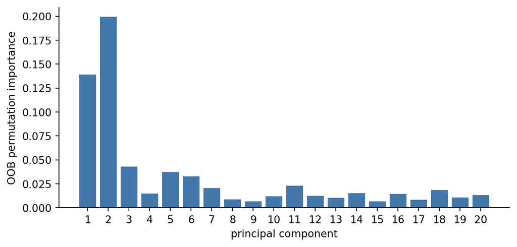

```
(c) test misclassification = 6/317 = 0.0189
pred    1    6    7
true
1     102    0    2
6       0  106    0
7       0    4  103
```

```python
import numpy as np, pandas as pd
import matplotlib.pyplot as plt
from rlt.estimators import RLT_cla

df = pd.read_csv("data/mnist-first2000.csv.gz"); lab = df.columns[0]
keep = [1, 6, 7]
tr = df.iloc[:1000][df.iloc[:1000][lab].isin(keep)]
te = df.iloc[1000:2000][df.iloc[1000:2000][lab].isin(keep)]
Xtr = tr.drop(columns=lab).to_numpy(float); ytr = tr[lab].to_numpy()
Xte = te.drop(columns=lab).to_numpy(float); yte = te[lab].to_numpy()

mu = Xtr.mean(0)                                   # center with training means only
Vt = np.linalg.svd(Xtr - mu, full_matrices=False)[2]
load = Vt[:20].T                                   # first 20 loadings
Ztr = (Xtr - mu) @ load; Zte = (Xte - mu) @ load
SEED = 43211

# (a) default settings
mdef = RLT_cla(n_estimators=1000, resample_replace=True, resample_prob=1.0,
               reinforcement=False, random_state=SEED).fit(Ztr, ytr)
print("train counts:", {d: int((ytr==d).sum()) for d in keep}, "| test:", len(yte))
print(f"(a) default (mtry={mdef.get_params()['mtry']}, node size={mdef.get_params()['min_samples_leaf']}) OOB = {mdef.oob_error_:.4f}")

# (b) tuning grid by OOB error
mtry_grid, nmin_grid = [2, 4, 6, 10], [1, 3, 5, 10]
grid = {}
for mt in mtry_grid:
    for nm in nmin_grid:
        grid[(mt, nm)] = RLT_cla(n_estimators=1000, mtry=mt, min_samples_leaf=nm,
            resample_replace=True, resample_prob=1.0, reinforcement=False,
            random_state=SEED).fit(Ztr, ytr).oob_error_
print("(b) OOB error grid (rows mtry, cols node size " + str(nmin_grid) + "):")
for mt in mtry_grid: print(f"  mtry {mt:2d}:", [round(grid[(mt, nm)], 4) for nm in nmin_grid])
best = min(grid, key=grid.get)
print("selected (mtry, node size):", best, "OOB =", round(grid[best], 4))

msel = RLT_cla(n_estimators=1000, mtry=best[0], min_samples_leaf=best[1],
    resample_replace=True, resample_prob=1.0, importance="permute",
    reinforcement=False, random_state=SEED).fit(Ztr, ytr)
imp = np.asarray(msel.feature_importances_).ravel()
plt.figure(figsize=(7, 3.4))
plt.bar(np.arange(1, 21), imp, color="#4477AA")
plt.xlabel("principal component"); plt.ylabel("OOB permutation importance")
plt.xticks(np.arange(1, 21)); plt.gca().spines[["top","right"]].set_visible(False)
plt.tight_layout(); plt.show()

# (c) final test assessment
pred = msel.predict(Zte); test_err = np.mean(pred != yte)
print(f"(c) test misclassification = {int((pred!=yte).sum())}/{len(yte)} = {test_err:.4f}")
print(pd.crosstab(pd.Series(yte, name="true"), pd.Series(pred, name="pred")).reindex(index=keep, columns=keep, fill_value=0).to_string())
```

**a.** The default forest (mtry picked by the package, node size 5) gives an OOB misclassification of about 0.043.

**b.** Across the grid, the best OOB error is at **mtry=2, node size=1** (OOB ≈ 0.028), beating the default. Low `mtry` helps here because the first couple of PCs carry almost all the class signal, so forcing splits to consider only a few features at a time decorrelates the trees without losing much. The permutation importance plot makes this concrete: PC2 and PC1 dominate (importance ≈ 0.20 and 0.14), with everything past PC3 contributing little. That lines up with PCA putting the directions of largest pixel variance first, and those directions happen to separate 1 vs 6 vs 7 well.

## Question 3: Planning a random-forest analysis skill

In earlier homework, some students wrote long skill files with detailed instructions, while others wrote short skills emphasizing their specific requirements or references. These approaches may perform differently depending on the AI and the task. A capable AI may already know standard ways to perform an analysis, so some instructions may be redundant, add little value, or sometimes make the analysis worse. It may be more useful to specify your personal choices for the analysis. An AI with more limited knowledge may benefit from detailed instructions that remind it of the steps to perform.

1. Write one paragraph describing how you would write a skill that directs an AI to perform a random-forest analysis and produce a report for a future dataset. Discuss how you would balance standard analysis instructions with your personal preferences, considering the AI’s capabilities.
2. Provide **10 instructions** you would consider including in the skill, **ordered from the most basic instructions to the more personal preferences**. Your list may cover computation, tuning, tables, figures, interpretation, presentation, or other aspects of a random-forest report.

You only need to discuss how the skill should be written. You are not required to write a complete skill file or test it.

### My answer

**a.** My guiding idea is that a capable model already knows how to fit a random forest, so I shouldn’t waste the skill telling it things like “import the package” or “a forest is an ensemble of trees.” Those instructions add length, and from the earlier peer review I saw that padding a skill with standard steps can actually hurt by crowding out the parts that matter. Instead I’d keep the mechanical, universally-agreed steps short (one line each, trusting the model to do them well) and spend most of the skill on the choices that are genuinely mine: which tuning grid to search, that I want OOB error rather than a separate validation split, that the test set stays untouched until the end, and exactly what the final report should contain and how long it can be. The one place I’d lean toward more detail is anywhere a model tends to cut corners even when it “knows better,” like leaking the test set into tuning or scaling on the full data, since a short reminder there is cheap insurance. So the balance is: assume competence on the standard mechanics, be explicit and opinionated about my preferences and the known failure modes.

**b.** Ten instructions, ordered from the most basic (things any RF analysis needs) to the most personal (my specific preferences):

1. Confirm the task type (classification or regression) and that the predictors are usable, and report n, the number of predictors, and the class balance or response summary.
2. Hold out a test set before any tuning and never touch it until the final evaluation.
3. Fit an ordinary random forest with a stated number of trees and bootstrap resampling.
4. Tune node size and `mtry`, since those are the two parameters that actually move the bias-variance tradeoff.
5. Estimate preprocessing (centering, any PCA) inside the training data only, and apply the same transform to held-out data.
6. Select the tuning setting by out-of-bag error rather than a separate validation split, because OOB comes free with the forest and uses all the training data.
7. Report the full tuning grid with its OOB errors, not just the winner, so the choice is auditable.
8. Include permutation variable importance for the selected model, and comment on which predictors actually drive it.
9. Present one compact figure (a tuning curve or importance plot) and one small table (grid results plus the final test error and confusion matrix), nothing decorative.
10. Keep the written report to one page in plain language: state the seed, the selected settings, the single test error, the main finding, and one honest limitation, and never retune after seeing the test result.